# Bellabeat Analysis - Capstone Project

Paul Dubois

## ASK

### Deliverables

- A clear summary of the business task
- a description of all data sources used
- documentation of any cleaning or manipulation off data
- a summary of your analysis
- supporting visualizations and key findings
- your top high-level content recommendations based on your analysis

### Business Task

As a junior analyst in the marketing team, I was tasked to find insights that can explain to us how consumers are using their smart devices by analyzing user’s smart device fitness data. Then apply these insights to a Bellabeat smart device products.

```r
#Load our packages into RStudio
library(tidyverse)
library(lubridate)
library(janitor)
```

```r
#working directory
getwd()
```

```
[1] "/Users/pauldubois/Documents/Google Cert/CAPSTONE PROJECT"
```

```r
#read in data
daily_activity <- read.csv("../CAPSTONE PROJECT/Fitabase Data 4.12.16-5.12.16/dailyActivity_merged.csv")
hourly_calories <- read.csv("../CAPSTONE PROJECT/Fitabase Data 4.12.16-5.12.16/hourlyCalories_merged.csv")
hourly_steps <- read.csv("../CAPSTONE PROJECT/Fitabase Data 4.12.16-5.12.16/hourlySteps_merged.csv")
sleep <- read.csv("../CAPSTONE PROJECT/Fitabase Data 4.12.16-5.12.16/sleepDay_merged.csv")
heartrate <- read.csv("../CAPSTONE PROJECT/Fitabase Data 4.12.16-5.12.16/heartrate_seconds_merged.csv")
```

```r
glimpse(daily_activity)
```

```
Rows: 940
Columns: 15
$ Id                       <dbl> 1503960366, 1503960366, 1503960366, 1503960366, 1503960366, 1503960366, 1503960366, 150…
$ ActivityDate             <chr> "4/12/2016", "4/13/2016", "4/14/2016", "4/15/2016", "4/16/2016", "4/17/2016", "4/18/201…
$ TotalSteps               <int> 13162, 10735, 10460, 9762, 12669, 9705, 13019, 15506, 10544, 9819, 12764, 14371, 10039,…
$ TotalDistance            <dbl> 8.50, 6.97, 6.74, 6.28, 8.16, 6.48, 8.59, 9.88, 6.68, 6.34, 8.13, 9.04, 6.41, 9.80, 8.7…
$ TrackerDistance          <dbl> 8.50, 6.97, 6.74, 6.28, 8.16, 6.48, 8.59, 9.88, 6.68, 6.34, 8.13, 9.04, 6.41, 9.80, 8.7…
$ LoggedActivitiesDistance <dbl> 0, 0, 0, 0, 0, 0, 0, 0, 0, 0, 0, 0, 0, 0, 0, 0, 0, 0, 0, 0, 0, 0, 0, 0, 0, 0, 0, 0, 0, …
$ VeryActiveDistance       <dbl> 1.88, 1.57, 2.44, 2.14, 2.71, 3.19, 3.25, 3.53, 1.96, 1.34, 4.76, 2.81, 2.92, 5.29, 2.3…
$ ModeratelyActiveDistance <dbl> 0.55, 0.69, 0.40, 1.26, 0.41, 0.78, 0.64, 1.32, 0.48, 0.35, 1.12, 0.87, 0.21, 0.57, 0.9…
$ LightActiveDistance      <dbl> 6.06, 4.71, 3.91, 2.83, 5.04, 2.51, 4.71, 5.03, 4.24, 4.65, 2.24, 5.36, 3.28, 3.94, 5.5…
$ SedentaryActiveDistance  <dbl> 0.00, 0.00, 0.00, 0.00, 0.00, 0.00, 0.00, 0.00, 0.00, 0.00, 0.00, 0.00, 0.00, 0.00, 0.0…
$ VeryActiveMinutes        <int> 25, 21, 30, 29, 36, 38, 42, 50, 28, 19, 66, 41, 39, 73, 31, 78, 48, 16, 52, 33, 41, 50,…
$ FairlyActiveMinutes      <int> 13, 19, 11, 34, 10, 20, 16, 31, 12, 8, 27, 21, 5, 14, 23, 11, 28, 12, 34, 35, 15, 24, 2…
$ LightlyActiveMinutes     <int> 328, 217, 181, 209, 221, 164, 233, 264, 205, 211, 130, 262, 238, 216, 279, 243, 189, 24…
$ SedentaryMinutes         <int> 728, 776, 1218, 726, 773, 539, 1149, 775, 818, 838, 1217, 732, 709, 814, 833, 1108, 782…
$ Calories                 <int> 1985, 1797, 1776, 1745, 1863, 1728, 1921, 2035, 1786, 1775, 1827, 1949, 1788, 2013, 197…
```

```r
cat("Number of participants:",n_distinct(daily_activity$Id)) #confirming number of participants is 33
```

```
Number of participants: 33
```

```r
cat("\nNumber of days recorded:", n_distinct(daily_activity$ActivityDate)) #checking the number of dates in the data
```

```
Number of days recorded: 31
```

```r
glimpse(hourly_calories)
```

```
Rows: 22,099
Columns: 3
$ Id           <dbl> 1503960366, 1503960366, 1503960366, 1503960366, 1503960366, 1503960366, 1503960366, 1503960366, 150…
$ ActivityHour <chr> "4/12/2016 12:00:00 AM", "4/12/2016 1:00:00 AM", "4/12/2016 2:00:00 AM", "4/12/2016 3:00:00 AM", "4…
$ Calories     <int> 81, 61, 59, 47, 48, 48, 48, 47, 68, 141, 99, 76, 73, 66, 110, 151, 76, 83, 124, 104, 132, 100, 65, …
```

```r
cat("Number of participants: ", n_distinct(hourly_calories$Id))
```

```
Number of participants:  33
```

```r
glimpse(hourly_steps)
```

```
Rows: 22,099
Columns: 3
$ Id           <dbl> 1503960366, 1503960366, 1503960366, 1503960366, 1503960366, 1503960366, 1503960366, 1503960366, 150…
$ ActivityHour <chr> "4/12/2016 12:00:00 AM", "4/12/2016 1:00:00 AM", "4/12/2016 2:00:00 AM", "4/12/2016 3:00:00 AM", "4…
$ StepTotal    <int> 373, 160, 151, 0, 0, 0, 0, 0, 250, 1864, 676, 360, 253, 221, 1166, 2063, 344, 489, 1386, 558, 1733,…
```

```r
cat("Number of participants: ", n_distinct(hourly_steps$Id))
```

```
Number of participants:  33
```

```r
glimpse(sleep)
```

```
Rows: 413
Columns: 5
$ Id                 <dbl> 1503960366, 1503960366, 1503960366, 1503960366, 1503960366, 1503960366, 1503960366, 150396036…
$ SleepDay           <chr> "4/12/2016 12:00:00 AM", "4/13/2016 12:00:00 AM", "4/15/2016 12:00:00 AM", "4/16/2016 12:00:0…
$ TotalSleepRecords  <int> 1, 2, 1, 2, 1, 1, 1, 1, 1, 1, 1, 1, 1, 1, 1, 1, 1, 1, 1, 1, 1, 1, 1, 1, 1, 1, 1, 1, 1, 1, 1, …
$ TotalMinutesAsleep <int> 327, 384, 412, 340, 700, 304, 360, 325, 361, 430, 277, 245, 366, 341, 404, 369, 277, 273, 247…
$ TotalTimeInBed     <int> 346, 407, 442, 367, 712, 320, 377, 364, 384, 449, 323, 274, 393, 354, 425, 396, 309, 296, 264…
```

```r
cat("Number of participants: ", n_distinct(sleep$Id))
```

```
Number of participants:  24
```

```r
cat("\nNumber of days recorded: ", n_distinct(sleep$SleepDay))
```

```
Number of days recorded:  31
```

```r
glimpse(heartrate)
```

```
Rows: 2,483,658
Columns: 3
$ Id    <dbl> 2022484408, 2022484408, 2022484408, 2022484408, 2022484408, 2022484408, 2022484408, 2022484408, 2022484408…
$ Time  <chr> "4/12/2016 7:21:00 AM", "4/12/2016 7:21:05 AM", "4/12/2016 7:21:10 AM", "4/12/2016 7:21:20 AM", "4/12/2016…
$ Value <int> 97, 102, 105, 103, 101, 95, 91, 93, 94, 93, 92, 89, 83, 61, 60, 61, 61, 57, 54, 55, 58, 60, 59, 57, 56, 58…
```

```r
cat("Number of participants: ", n_distinct(heartrate$Id))
```

```
Number of participants:  14
```

## Data Processing

```r
cleaned_daily_activity <- clean_names(daily_activity) %>%  #DAILY ACTIVITY
  rename(date = activity_date) %>%
  remove_empty(which = c("rows")) %>%
  remove_empty(which = c("cols"))

cleaned_daily_activity$date <- as_date(cleaned_daily_activity$date, format = "%m/%d/%Y")

cleaned_sleep <- clean_names(sleep) %>% #DAILY SLEEP
  rename(date = sleep_day) %>%
  remove_empty(which = c("rows")) %>%
  remove_empty(which = c("cols"))

cleaned_sleep$date <- as_date(cleaned_sleep$date, format = "%m/%d/%Y")

cleaned_hourly_steps <- clean_names(hourly_steps) %>% # HOURLY STEPS
  remove_empty(which = c("rows")) %>%
  remove_empty(which = c("cols"))

cleaned_hourly_calories <- clean_names(hourly_calories) %>% #HOURLY CALORIES
  remove_empty(which = c("rows")) %>%
  remove_empty(which = c("cols"))
```

> All datasets are presumed cleaned and verified for data integrity. Next we take a `glimpse()` at each dataset to confirm our data cleaning

```r
glimpse(cleaned_daily_activity)
```

```
Rows: 940
Columns: 15
$ id                         <dbl> 1503960366, 1503960366, 1503960366, 1503960366, 1503960366, 1503960366, 1503960366, 1…
$ date                       <date> 2016-04-12, 2016-04-13, 2016-04-14, 2016-04-15, 2016-04-16, 2016-04-17, 2016-04-18, …
$ total_steps                <int> 13162, 10735, 10460, 9762, 12669, 9705, 13019, 15506, 10544, 9819, 12764, 14371, 1003…
$ total_distance             <dbl> 8.50, 6.97, 6.74, 6.28, 8.16, 6.48, 8.59, 9.88, 6.68, 6.34, 8.13, 9.04, 6.41, 9.80, 8…
$ tracker_distance           <dbl> 8.50, 6.97, 6.74, 6.28, 8.16, 6.48, 8.59, 9.88, 6.68, 6.34, 8.13, 9.04, 6.41, 9.80, 8…
$ logged_activities_distance <dbl> 0, 0, 0, 0, 0, 0, 0, 0, 0, 0, 0, 0, 0, 0, 0, 0, 0, 0, 0, 0, 0, 0, 0, 0, 0, 0, 0, 0, 0…
$ very_active_distance       <dbl> 1.88, 1.57, 2.44, 2.14, 2.71, 3.19, 3.25, 3.53, 1.96, 1.34, 4.76, 2.81, 2.92, 5.29, 2…
$ moderately_active_distance <dbl> 0.55, 0.69, 0.40, 1.26, 0.41, 0.78, 0.64, 1.32, 0.48, 0.35, 1.12, 0.87, 0.21, 0.57, 0…
$ light_active_distance      <dbl> 6.06, 4.71, 3.91, 2.83, 5.04, 2.51, 4.71, 5.03, 4.24, 4.65, 2.24, 5.36, 3.28, 3.94, 5…
$ sedentary_active_distance  <dbl> 0.00, 0.00, 0.00, 0.00, 0.00, 0.00, 0.00, 0.00, 0.00, 0.00, 0.00, 0.00, 0.00, 0.00, 0…
$ very_active_minutes        <int> 25, 21, 30, 29, 36, 38, 42, 50, 28, 19, 66, 41, 39, 73, 31, 78, 48, 16, 52, 33, 41, 5…
$ fairly_active_minutes      <int> 13, 19, 11, 34, 10, 20, 16, 31, 12, 8, 27, 21, 5, 14, 23, 11, 28, 12, 34, 35, 15, 24,…
$ lightly_active_minutes     <int> 328, 217, 181, 209, 221, 164, 233, 264, 205, 211, 130, 262, 238, 216, 279, 243, 189, …
$ sedentary_minutes          <int> 728, 776, 1218, 726, 773, 539, 1149, 775, 818, 838, 1217, 732, 709, 814, 833, 1108, 7…
$ calories                   <int> 1985, 1797, 1776, 1745, 1863, 1728, 1921, 2035, 1786, 1775, 1827, 1949, 1788, 2013, 1…
```

```r
glimpse(cleaned_hourly_calories)
```

```
Rows: 22,099
Columns: 3
$ id            <dbl> 1503960366, 1503960366, 1503960366, 1503960366, 1503960366, 1503960366, 1503960366, 1503960366, 15…
$ activity_hour <chr> "4/12/2016 12:00:00 AM", "4/12/2016 1:00:00 AM", "4/12/2016 2:00:00 AM", "4/12/2016 3:00:00 AM", "…
$ calories      <int> 81, 61, 59, 47, 48, 48, 48, 47, 68, 141, 99, 76, 73, 66, 110, 151, 76, 83, 124, 104, 132, 100, 65,…
```

```r
glimpse(cleaned_hourly_steps)
```

```
Rows: 22,099
Columns: 3
$ id            <dbl> 1503960366, 1503960366, 1503960366, 1503960366, 1503960366, 1503960366, 1503960366, 1503960366, 15…
$ activity_hour <chr> "4/12/2016 12:00:00 AM", "4/12/2016 1:00:00 AM", "4/12/2016 2:00:00 AM", "4/12/2016 3:00:00 AM", "…
$ step_total    <int> 373, 160, 151, 0, 0, 0, 0, 0, 250, 1864, 676, 360, 253, 221, 1166, 2063, 344, 489, 1386, 558, 1733…
```

```r
glimpse(cleaned_sleep)
```

```
Rows: 413
Columns: 5
$ id                   <dbl> 1503960366, 1503960366, 1503960366, 1503960366, 1503960366, 1503960366, 1503960366, 1503960…
$ date                 <date> 2016-04-12, 2016-04-13, 2016-04-15, 2016-04-16, 2016-04-17, 2016-04-19, 2016-04-20, 2016-0…
$ total_sleep_records  <int> 1, 2, 1, 2, 1, 1, 1, 1, 1, 1, 1, 1, 1, 1, 1, 1, 1, 1, 1, 1, 1, 1, 1, 1, 1, 1, 1, 1, 1, 1, 1…
$ total_minutes_asleep <int> 327, 384, 412, 340, 700, 304, 360, 325, 361, 430, 277, 245, 366, 341, 404, 369, 277, 273, 2…
$ total_time_in_bed    <int> 346, 407, 442, 367, 712, 320, 377, 364, 384, 449, 323, 274, 393, 354, 425, 396, 309, 296, 2…
```

## Analysis & Data Visualization

- Is there a relationship between variables in the daily_activity dataset?

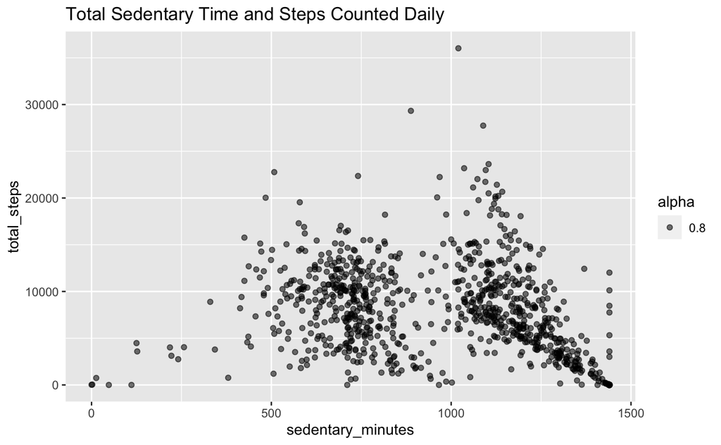

```r
ggplot(data = cleaned_daily_activity) +
  geom_point(mapping = aes(x = sedentary_minutes, y = total_steps, alpha = 0.8)) +
  labs(title = "Total Sedentary Time and Steps Counted Daily")
```

> Using `ggplot` to create a data viz that shows the relationship between total steps in the day and sedentary minutes. Observing this, we find that your daily activity is not closely related to the total steps taken in a day. There are two visual clusters in our scatter plot, they are both visualize the same number of steps although one cluster has more sedentary time. So we consider that not all steps are considered active.